# Introduction to Python

# Graphs

As we know, a *graph* is the word often used in maths and computer science for a *network* -- a collection of objects with connections among them.

Graph theory is a beautiful and fascinating branch of mathematics with many applications in computer science, artificial intelligence, and applications.

Don't confuse a graph (network) with a graph (plot).

Some of the disparate terminology we use:

| object | connection |
| --- | --- |
| node | edge |
| vertex | arc |
| point | line |

[figure not shown]

[Wiki](https://en.wikipedia.org/wiki/Seven_Bridges_of_K%C3%B6nigsberg)

The *founding problem of graph theory*: is it possible to traverse all the bridges of Konigsberg and end back at the starting-point without re-crossing any? Here the *nodes* are pieces of land and *edges* are bridges.

[figure not shown]

A practical problem: what is the shortest path from one location to another, via a network of roads?

[figure not shown]

Credit: http://bitcoinwiki.co/wp-content/uploads/censorship-free-social-network-akasha-aims-to-tackle-internet-censorship-with-blockchain-technology.jpg

A classic social networks problem: who are the most influential people? How many steps or "degrees of separation" from one to the next?

[figure not shown]

Inspired by Yannakakis and Togelius, *Artificial Intelligence and Games*

FSMs are graphs, where states are nodes and state transitions are *directed edges* and input symbols are edge labels.

With directed edges, we draw them as an arrow (as in the FSM) because order matters: $i \rightarrow j$ is not the same as $j \rightarrow i$.

### The web

- Web pages (URLs) are nodes; hyperlinks are directed edges.

[figure not shown]

[Wiki](https://en.wikipedia.org/wiki/PageRank)

The *PageRank* problem: which pages are the most trusted? A page is trusted if other highly trusted pages link to it. But isn't this circular?

### Edge properties

In all the examples we've seen, nodes have names or just integer labels.

Usually edges are just plain connections with no properties, names or labels (sometimes direction). Sometimes edges do have properties such as a numerical *weight* per edge.

E.g. in a **water grid**, each edge might represent a pipe, and each pipe might have a different capacity represented as a number in litres per second.

### Collaboration graphs

E.g. in scientific research: authors are nodes; there is an edge where two authors have co-authored a paper.

Here edges are *undirected* because saying "a co-authored with b" is the same as saying "b co-authored with a".

A classic problem of social networks: can we automatically detect communities?

### Electrical grids

- The electricity network: power stations, transformers, and consumers are nodes; electricity wires are edges.

[figure not shown]

A classic logistics problem: on a small island, we have a power station and a set of consumers. Every meter of electricity wires costs money. What wires should we build to save money but ensure everyone is connected?

### Family trees

A *tree* is a graph with no cycles. Your family tree is a directed tree *rooted* at you, with an edge from each person to each of their parents.

[figure not shown]

[Time.com](https://time.com/5560753/game-of-thrones-family-tree/)

By the way, it's not *really* a tree, if we go back far enough.

### Abstract syntax tree

An AST is an internal representation for computer code. The Python interpreter, the C++ compiler, and all other interpreters and compilers translate our source code into an AST before executing it.

```
def fib(n):
    if n < 2:
        return n
    else:
        return fib(n-1) + fib(n-2)
```

[figure not shown]

Tangent: Python has some nice built-in tools for *introspection* including looking at the AST of a piece of Python code. It's not quite as clean as the example above because it includes extra technical details.

```
import ast
s = open("code/fib2.py").read()
n = ast.parse(s)
print(ast.dump(n))
```

```
"Module(body=[FunctionDef(name='fib', args=arguments(args=[arg(arg='n', annotation=None)], vararg=None, kwonlyargs=[], kw_defaults=[], kwarg=None, defaults=[]), body=[If(test=Compare(left=Name(id='n', ctx=Load()), ops=[Lt()], comparators=[Num(n=2)]), body=[Return(value=Name(id='n', ctx=Load()))], orelse=[Return(value=BinOp(left=Call(func=Name(id='fib', ctx=Load()), args=[BinOp(left=Name(id='n', ctx=Load()), op=Sub(), right=Num(n=1))], keywords=[]), op=Add(), right=Call(func=Name(id='fib', ctx=Load()), args=[BinOp(left=Name(id='n', ctx=Load()), op=Sub(), right=Num(n=2))], keywords=[])))])], decorator_list=[], returns=None)])"
```

(The details of this are not examinable.)

### Project planning

In project management, we often decompose a project into a large list of tasks to be accomplished by many different people using various resources. Some of these tasks have *dependencies*: task $j$ cannot be started until we have the output of task $i$. This induces a directed graph.

- What would a *cycle* in such a graph mean?

Assuming no cycles, we can perform a *topological sort*, which just means ordering the tasks so that for any dependency $(i, j)$, task $j$ is sorted *after* task $i$. Creating this ordering allows us to create a timeline and identify tasks which can be done in parallel.

**Exercise**. Suppose we have the following tasks. Identify the dependencies, draw the dependency graph to confirm there are no cycles, then write down a topological sort. Which tasks can be done in parallel?

| tasks | more tasks | more tasks |
| --- | --- | --- |
| get coffee from fridge | fill mocha with water | put coffee in mocha |
| close mocha | heat mocha | get cup |
| get spoon | get sugar from cupboard | put sugar in cup |
| pour coffee into cup | stir | put coffee away |

put sugar away

### Software installation

A related example is the dependency graph of software libraries. As we know:

- Seaborn can only work if Matplotlib is installed;
- Scipy requires Numpy;
- Pandas requires Numpy;
- and so on.

A classic problem in software management: recursively finding all the necessary dependencies for a library.

Next time you install a new library using Anaconda, take a look at all the other libraries that it depends on.

### Data-flow graphs

Nodes are computations, and edges represent the results of computations being used as inputs in later computations.

[figure not shown]

From [Hazelcast.com](https://hazelcast.com/glossary/directed-acyclic-graph)

### Node and graph terminology and properties

- Order: the number of nodes in the graph
- Size: the number of edges in the graph.

### Cycles

- Cycle: a sequence of 2+ nodes with edges allowing travel from start, along sequence, leading back to start
- Directed cycle: in a directed graph, a cycle exists only if this travel is consistent with edge direction
- A graph with no cycles is called *acyclic*.
- The *degree* of node *n* is the number of neighbours
- In a *directed graph*, we have a separate *out-degree* and *in-degree*
- In a graph with *weighted edges*, the degree is the sum of relevant edge weights.

### Graph representations

There are several possible representations for a graph:

- Adjacency matrix
- List of edges
- Adjacency-list
- dict-of-dicts-of-dicts, as used by NetworkX, is a variant of adjacency-list.

### Adjacency matrix

In an adjacency matrix, we represent a graph of $n$ nodes as an $n\times n$ matrix. In a binary adjacency matrix, a 0 in location $(i, j)$ indicates no edge present between nodes $i$ and $j$; a 1 indicates the edge is present.

If our edges have weights, we just put those instead of the "1"s.

### Conclusion

Graph theory is the study of things that can be represented as graphs. And a *lot* of things can be represented as graphs.

Classroom MScAI students can study more in the module Web and Network Science, CT5113, Dr Conor Hayes, Semester 2.

### Exercises

- The "adjacency lists" representation is really more like a dictionary, where every node maps to a list of its neighbours, i.e. the nodes which are *adjacent* to it. Here is a graph in adjacency-lists format:

  ```
  G = {
    0: [1, 2, 3],
    1: [0, 3],
    2: [0],
    3: [0, 1],
    4: []}
  ```

Draw this on paper. Write down its adjacency matrix on paper.

- Calculate the sum of row 0 in the adjacency matrix. What does it mean?
- What do you observe about the diagonal?
- Suppose you saw a 1 on the diagonal. How could this be represented on paper? Think of a real-world situation where this would be useful.
- Draw a new *directed* graph of 5 nodes and write its adjacency matrix. What do you notice?
- We could also represent a graph as a list of edges, where each edge is a 2-tuple. What would be the advantages of this, for a very large sparse graph? Are there any disadvantages?

### Solutions

Adjacency matrix

```
0 1 1 1 0
1 0 0 1 0
1 0 0 0 0
1 1 0 0 0
0 0 0 0 0
```

[figure not shown]

- The row-sum of a node (e.g. row 0 for node 0) is its degree -- the number of edges from it.
- The diagonal is always 0.
- If there was a 1 on the diagonal, it would indicate an edge from node $i$ to itself -- a *self-loop*. Usually these are disallowed. But e.g. if a web page linked to itself, we could represent that as a self-loop.
- In an undirected graph, the adjacency matrix is symmetric. In a directed graph, it may not be.
- The advantage of the list-of-edges representation is that in a *sparse graph* (few edges, relative to the number there *could be*) it saves a lot of space compared to an explicit adjacency matrix. The possible disadvantage is that there could be isolated nodes (nodes with no neighbours, i.e. degree 0), which would be omitted entirely if we only list the edges. So we might have to maintain both a list of edges and a list of nodes.

### Exercise -- only for fun

There are many neat puzzles which use graphs and graph theory.

The following puzzle is enacted here https://www.youtube.com/watch?v=a1DUUnhk3uE, and is derived from the book by Bellos featured in that video.

The scenario in the puzzle is:

There are 10 prisoners in the breakfast room, numbered 1-10. In a room, there are 10 closed boxes, numbered 1-10, each containing 1 playing card, numbered 1-10. Each prisoner is allowed to enter the room, open a box to observe the card, re-close it, and repeat to observe 5 cards. They then exit to their cell. The prisoners can communicate before the start, in the breakfast room, but not during or after observing the cards.

Their goal is for every prisoner to observe his/her own number. If they all do so, they walk free. Otherwise, they serve a long sentence.

There is no solution that guarantees they'll walk free, but there is a deterministic approach which improves their chances a lot, relative to random.

- What are their chances with a random strategy?
- What improvement can they make?

### Hint

The right strategy is for each prisoner to start at the box numbered with their own number, say $i$. If it contains card $i$, they win and exit. Else, if it contains card $j$, they go to box $j$, and so on until they have observed 5 cards and have to leave.

- Use a directed graph to model the process.
- Explain why it helps.
- In Python, implement the process; sample many possible distributions of cards; for each, run the process to eventually calculate their expected "win rate".

### Exercise -- only for fun

"A calculator has only 3 buttons. The first multiplies the current value by 3, the second adds 2 and the third subtracts 2. Starting with 0 what is the least number of presses you need to reach 100?"

-- https://puzzling.stackexchange.com/questions/91090/three-button-calculator

This is a *shortest-path* problem in a graph. Every integer is a node, and e.g. there is an edge from 0 $\rightarrow$ 2 because we can press the `+2` button. However, the graph is infinite, so we can't just create it and then use a shortest-path algorithm. A classic solution is to use breadth-first search, creating the graph as we go.

```python
import networkx as nx
state = 0
known = {state}
target = 100
moves = [lambda x: x*3,
         lambda x: x+2,
         lambda x: x-2]
frontier = known # the states we have just reached on previous step
steps = 0
print(steps, known)
while target not in known:
    newfrontier = set() # the states we reach for the first time on this step
    for state in frontier:
        for move in moves:
            newstate = move(state)
            if newstate not in known:
                newfrontier.add(newstate)
    known = known.union(newfrontier)
    frontier = newfrontier
    steps += 1
    print(steps, known)
```

```
0 {0}
1 {0, 2, -2}
2 {0, 2, 4, 6, -6, -4, -2}
3 {0, 2, 4, 6, 8, 12, -18, 18, -12, -8, -6, -4, -2}
4 {0, 2, 4, 6, 8, -54, 10, 12, 14, 16, 18, 20, 24, -36, 36, -24, -20, -18, -16, -14, -12, 54, -10, -8, -6, -4, -2}
5 {0, 2, 4, 6, 8, 10, 12, 14, 16, 18, 20, -108, 22, 24, 26, 30, 34, 162, 36, 38, 42, 48, 52, 54, -72, 56, 60, -60, -56, 72, -54, -52, -48, -42, -38, -36, -162, -34, -30, -26, -24, -22, -20, 108, -18, -16, -14, -12, -10, -8, -6, -4, -2}
6 {0, 2, 4, 6, 8, 10, 12, 14, 16, 18, 20, 22, 24, 26, -486, 28, 30, 32, 34, 36, 38, 40, -216, 42, 44, 46, 48, 50, 52, 54, 56, 58, 60, 62, 66, 324, 70, 72, 74, -180, 78, -168, 90, -164, -162, -160, -156, 102, 106, 108, 110, -144, 114, 126, -126, -114, 144, -110, -108, -106, -102, 156, 160, 162, 164, …
7 {0, 2, 4, 6, 8, -504, 10, 12, 14, 16, 18, 20, -492, 22, 24, -488, 26, -486, 28, -484, 30, 540, 32, -480, 34, 36, 38, 40, 42, 44, -468, 46, 48, 50, 52, -972, 54, 56, 58, 60, 62, 64, 66, 68, 70, 72, 74, 76, 78, -1458, 80, -432, 84, 88, 90, 92, 96, 100, 102, 104, 106, 108, 110, 112, 114, 116, 120, 12…
```

To improve this, we should track the path required to reach each new state. (Or we could just stop, put everything in a NetworkX graph, and run an ordinary shortest-path algorithm.)

[figure not shown]

# NetworkX

NetworkX https://networkx.github.io/ is a nice library of graph algorithms in Python. It can be installed via Anaconda.

We previously saw several possible representations for graphs which can be used in computer programs:

- Adjacency matrix
- List of edges
- Adjacency lists

The adjacency list format is like this. For each node, we store its list of neighbours:

```
G = {
    0: [1, 2, 3],
    1: [0, 3],
    2: [0],
    3: [0, 1],
    4: []
}
```

Next, we'll see that the NetworkX representation is just an extension of this, allowing for each edge to have extra properties such as weights.

```python
G = {
    0: {1: {"w": 0.5}, 2: {"w": 0.1}, 3: {"w": 0.1}},
    1: {0: {"w": 0.5}, 3: {"w": 0.3}},
    2: {0: {"w": 0.1}},
    3: {0: {"w": 0.1}, 1: {"w": 0.3}},
    4: {}
}
```

One way to make a graph in NetworkX is just to build it up by adding nodes and then edges, as follows. (Later we'll see how to read graphs in.)

```python
import networkx as nx # conventional import
G = nx.Graph()
G.add_nodes_from(range(5))
```

```python
G.nodes()
```

```
NodeView((0, 1, 2, 3, 4))
```

```python
G.edges()
```

```
EdgeView([])
```

```python
G.add_edge(0, 1, w=0.5)
G.add_edge(0, 2, w=0.1)
G.add_edge(0, 3, w=0.1)
G.add_edge(1, 3, w=0.3)
```

```python
G.edges()
```

```
EdgeView([(0, 1), (0, 2), (0, 3), (1, 3)])
```

```python
G.edges(data=True)
```

```
EdgeDataView([(0, 1, {'w': 0.5}), (0, 2, {'w': 0.1}), (0, 3, {'w': 0.1}), (1, 3, {'w': 0.3})])
```

And now, notice that `G` itself functions as a `dict`, mapping from a node to its adjacency list **with edge properties**:

```python
for node in G.nodes():
    print(node, ":", G[node])
```

```
0 : {1: {'w': 0.5}, 2: {'w': 0.1}, 3: {'w': 0.1}}
1 : {0: {'w': 0.5}, 3: {'w': 0.3}}
2 : {0: {'w': 0.1}}
3 : {0: {'w': 0.1}, 1: {'w': 0.3}}
4 : {}
```

The nodes don't have to be integers! They can be strings, floats, or arbitrary (hashable) Python objects.

(Remember mutable objects such as lists are not hashable and cannot be stored in dictionaries.)

- `G = nx.Graph() # default, undirected`
- `G = nx.DiGraph() # directed graph`

### Algorithms

- Creating standard graphs and random graphs
- Breadth-first and depth-first traversal
- Connectivity
- Communities, cliques, clusters, etc.
- Isomorphism (are two graphs the same if we ignore labels)

### More algorithms

- Centrality e.g. PageRank and related algorithms
- Cycles
- Shortest paths
- Max-flow/min-cut
- Diameter
- Linear algebra methods on adjacency matrices

### Exercise

We'll see how to read in a graph to NetworkX from a plain-text format, and run some algorithms on it. The scenario is: on a small island, we are just about to finish building a power plant at town 0. All the towns are already connected by a road network. The Minister has decided to build the electricity network along the roads. We want to achieve connectivity to all towns at minimum cost. Our data is stored in `data/power_plant_edgelist.csv`.

1. As we can see in the first few lines below, it is just an edge-list with weights. Why are we not worried about the possibility of isolated nodes, not captured by the edge list?

```python
import networkx as nx
fname = "data/power_plant_edgelist.csv"
f = open(fname)
for i in range(10):
    print(f.readline(), end="")
f.close()
```

```
# This file contains the road structure
# on a small island. Towns are
# at nodes 0-13. Each road segment is
# notated as:
# town town distance
0 1 0.200000
0 2 0.223607
0 3 0.500000
0 4 0.282843
0 5 0.500000
```

### Exercises

1. Read in this file using `nx.read_edgelist`. It should be an undirected, weighted graph.
2. Confirm that the road network is fully connected. Use `nx.is_connected()`.
3. Use Kruskal's Minimum Spanning Tree to find the lowest-cost electricity network.
4. The Minister is planning to take a drive in her Mercedes when she comes to cut the ribbon. She will travel from the power plant to the most distant village, using the fastest route. What is that distance?

### Solutions

The tricky part is the syntax for the edge data, in this case the weights. It is not a tuple ("weight", float) -- it is a sequence of tuples, one tuple for each piece of edge data. There's only one piece of edge data, so it is a sequence of one tuple.

```python
G = nx.read_edgelist(fname, create_using=nx.Graph, nodetype=int, data=[("weight", float)])
```

Some graph properties:

```python
G.order()
```

```
14
```

```python
G.size()
```

```
56
```

Confirm that the graph is connected, ie no isolated villages:

```python
nx.is_connected(G)
```

```
True
```

*Kruskal's Minimum Spanning Tree* algorithm finds an MST, that is a tree with the same nodes as the original, and a subset of the edges, such that in the tree all nodes are connected, and the sum of edge-weights in the tree is as small as possible. This solves the problem of building the electricity network because the cost of constructing an edge is proportional to the edge distance.

```python
mst = nx.minimum_spanning_tree(G)
```

```python
# how many edges? a tree always has n-1
mst.size()
```

```
13
```

```python
# What is the total cost of constructing the network?
sum(mst[e0][e1]["weight"] for e0, e1 in mst.edges())
```

```
4.423083999999999
```

*Dijkstra's algorithm* is a famous algorithm for finding the shortest path from a node to all other nodes. Here "shortest path" takes account of edge weights. In our case, the edge weight is a measure of the distance. We have to say which node we want to start from (0) and which edge property to use ("weight").

```python
node_dists, paths = nx.single_source_dijkstra(G, 0,
                                              weight="weight")
```

Now we just find the most distant village:

```python
farthest = max(node_dists, key=lambda n: node_dists[n])
```

```python
farthest
```

```
12
```

```python
node_dists[farthest]
```

```
1.0830950000000001
```

By the way, the Stanford Large Network Dataset collection https://snap.stanford.edu/data/ has lots of interesting graphs for further investigations.

[figure not shown]

# Version control, `git`, and GitHub

Has this ever happened to you?

```
$ ls
assignment.py
assignment2.py
assignment_from_Tom.py
assignment2_from_Tom.py
assignment2_from_Tom2.py
assignment_final.py
assignment_FINAL_with_Toms_changes_merged_except_spelling.py
assignment_final_5pm_missing_some_changes.py
```

A *version control* system is a system for controlling multiple versions of a file. There can be multiple collaborators working remotely, and multiple versions, with automatic merging of changes.

Version control also serves as a *history*, a *backup*, and (if you want) a *public repository*.

### Diff and patch

Version control usually works on plain text files. E.g. a `.txt` file, or a `.py` or `.java` file is plain text. Word `.docx` files are not, but people working on documents (as opposed to program code) might write them in Markdown or LaTeX, which are plain-text formats that convert into `pdf`s or `html`.

A fundamental concept is the *diff*. A diff is a line-by-line list of differences between two plain text files.

**`file_a.py`**

```
x = 3
a = "elephant"
print("hello")
```

**`file_b.py`**

```
x = 3
a = "lion"
print("hello")
```

The *diff* between the two files would look like this:

```
2c2
< a = "elephant"
---
> a = "lion"
```

There is also a program `patch` which can take `file_a.py` and *apply* the diff, to produce `file_b.py`.

This is useful, because it allows two people to start on a common file, work *independently*, and then merge their changes whenever they want. A version control system uses `diff` and `patch` internally (that's why we didn't show how to do it manually, above).

In fact, `diff` and `patch` together give rise to an *algebra* of versions -- the theory that underlies version control.

[figure not shown]

### Common version control systems

There are several version control systems in common use, including

- Subversion
- Git
- Mercurial
- Bitkeeper (\$)
- Perforce (\$)

There are several places online where you can use free online version control services. E.g. for Subversion there is https://riouxsvn.com/. For git there is http://www.github.com/. We will concentrate on git and Github. Remember, git is the name of the version control system, and Github is a company which provides a nice website with free (and pay-for) git hosting. A lot of people working in software and analytics use their Github account as a CV.

Sadly, git and Github are really complex. Happily, we can avoid most of the complexity. We just need to know a few simple things:

- How to create a new repository on Github
- How to clone the repository from Github to our disk
- How to add a new file to our local copy
- How to push from our local copy to Github
- A little about branches, merges, and merge conflicts.

Next, we'll carry out these basic tasks in a live Github repo. Don't worry, you can delete the repo after.

Before proceeding, make an account on Github, and log in to it.

### Creating a new repository

[figure not shown]

- Click "New", then enter a name (no spaces or weird punctuation), e.g. "test", and a description, e.g. "My first test repository"
- Then choose "public" and tick "Initialize this repository with a README".

Now the repository will be created, and a `README.md` file will be created inside it. You can look at the list of files in the repository and get the clone URL of the repository (needed for the next step). You can also download the entire thing as a zip, but we won't normally proceed that way.

[figure not shown]

### Cloning

To get the new repository onto your local disk, you *clone*. Type the following at your command prompt. Obviously, put in the appropriate clone URL for your new repository in place of the one I have mentioned.

```
git clone https://github.com/jmmcd/ML-snippets.git
```

You'll get a new directory, in your current directory, containing one file: `README.md`. Open it up in a text editor and have a look.

### Adding a new file

Now, let's write a new Python program, say `test.py`, and save it in the same directory as `README.md`. We have to tell Git that it exists, and *commit* it.

```
git add test.py
git commit -m "Wrote a simple test program."
```

### Please tell me who you are

If we see the message `Please tell me who you are`, it's because git needs to associate every commit with the person who made it. It helpfully tells us what to do:

```
git config --global user.email "you@example.com"
git config --global user.name "Your Name"
```

### What does *commit* mean?

When you commit, you're saying the current version of the code is in a consistent state (i.e. no half-finished changes). It's not necessarily *complete* or perfect. Usually, you commit with messages like these:

- `git commit -m "Fixed a bug in calculation of y."`
- `git commit -m "Added a new function to print stats."`
- `git commit -m "Expanded documentation."`

In order to commit, you always `add` first, to tell `git` which files you want to commit.

### Pushing

So far, we've added a new file and committed it, but that only affects our local (on-disk) repository. Next we have to *push* to Github.

```
git push
```

(You will be asked for your Github password.)

After this finishes, you can reload the web page to see your `test.py` has appeared on Github.

### Changing and committing

Previously, we added a new file and then committed. Even if we *edit* an existing file, we still have to run add (it really means "add the file to an upcoming commit", rather than "add to the repository") and then commit.

So, try adding some text to the README.md, then add, commit with an appropriate message, and push.

### Pulling

Suppose your colleague is working in the same repository. To check whether they've committed and pushed any changes, you can run:

```python
git pull
```

It gets any changes from github and applies them to your local repository. If necessary it uses *merge* so that your colleague's changes and your own are merged together.

### Typical (simple) workflow on a single repo

```
git pull # get any changes by others
# edit test.py in text editor
git add test.py # tell git that test.py will be committed
git commit -m "Change to tigers" # commit
git push # push changes to GitHub
```

### Walk-through 1

1. On Github, make a new repository by clicking "New".
2. Initialise it with a README.
3. Clone to our hard disk.
4. Make a new file `test.py`.
5. Add, commit, push.
6. See the changes on Github.
7. Make a change directly on Github.
8. Pull that to hard disk.

### Merge conflicts

If we are working with colleagues in a single repository, we may see *merge conflicts*. A merge conflict arises when two people push incompatible changes (e.g. I changed lion to elephant, and `commit`ted, and at the same time you changed lion to antelope, and `commit`ted, and then we both `push`ed).

In a merge conflict, we'll see a message like this from `git`:

```
git pull
[...]
CONFLICT (content): Merge conflict in test.py
```

`git` will also put some special markers in the conflicted file. They show the chunks of text that is coming from the remote repo (Github), and the text in our working copy (on disk):

```
<<<<<<<
a = "tiger"
=======
a = "elephant"
>>>>>>>
```

To solve this, we have to edit the file to decide which version is better, remove all the special markers `<<<` `===` and `>>>`, and then save it, `add` and `commit` with an appropriate message.

### Walk-through 1 (part 2)

1. Make a change directly on Github.
2. Make a conflicting change on hard disk.
3. Try to pull and observe problem.
4. Try to commit and pull, still observe problem.
5. Resolve merge conflict by editing the markers.
6. Add, commit, push and see result in Github.

### Branching

[figure not shown]

From atlassian.com

A more common workflow uses *branching*. When we are about to start a new work item such as fixing a bug, we tell Git to create a branch for that work item. That branch starts as a copy of the current master branch. We commit items to our new branch and push. When we're ready with the work item, we can *merge* it back to the master branch and delete it.

```
git checkout -b big_feature # create branch
# work on test.py in text editor
git add test.py
git commit -m "Created fab new function in test.py"
# maybe keep working for a few hours, days or weeks and then
git checkout master # switch to master branch
git merge big_feature # merge the branch onto master
git branch -d big_feature # delete branch
git push # push to github
```

### Pull requests

A further complication is that in many collaborative situations there is one person or organisation which controls the repository, but others want to make edits. The way to do this is: we *fork* the person's repository in Github, so that there is a new repo of the same name under our Github account:

[figure not shown]

Then clone that to our local computer, create a branch, and work until our work is done on that branch, and push it back to our copy of the repo on Github.

Then we create a *pull request*. The easiest way to do this is by going to the organisation's repository on Github and clicking "New pull request". There are then some buttons to click, basically telling the organisation which of our branches we want them to merge changes from.

[figure not shown]

The organisation may have a review policy, they may have their own code/commenting style, etc., which we should obey.

### Git complexity

There is a lot more going on in Git. What we have covered is enough to get started. There are many guides which you could consider, e.g.:

- https://www.atlassian.com/git/tutorials
- https://rogerdudler.github.io/git-guide/
- https://guides.github.com/introduction/flow/

If you see something out of the ordinary, Stackoverflow is a good place to look it up.

### Walk-through 2

We'll walk through these steps using `networkx`:

1. Go to the repo page on Github, e.g. `networkx/networkx`.
2. On Github, fork it to your account e.g. `jmmcd/networkx`.
3. Clone that to your local machine using `git clone`.
4. Go into the directory and make a branch using `git checkout -b`.
5. Make some changes on that branch, add, commit.
6. Merge that branch to our master and delete the branch.
7. Push to our Github.
8. Make a pull request. # DON'T DO THIS

[figure not shown]

# Regular Expressions

In Computer Science, a (formal) **language** is defined as *a set of strings*.

`L = {"b", "ab", "aab", "aaab"}` is a language defined by enumeration.

`L = {strings of length 1...4, starting with zero or more 'a's and ending in exactly 1 'b'}` is the same language defined by a rule.

`L = {valid email addresses according to RFC2822}` is a language. https://tools.ietf.org/html/rfc2822

`L = {valid Python files}` is a language too, defined partly by Python docs and also, partly, perhaps implicitly by the behaviour of the Python interpreter.

There are two main things we might want to do with languages.

1. *Recognize* strings, i.e. check whether a given string is in the language;

   a. Just check, i.e. return True/False;

   b. Check, and (assuming True), extract some of the structure or contents of the string;
2. *Generate* strings, i.e. generate 1 or more random strings from the language.

There are several different techniques suitable for *recognising* different types of languages:

- manual testing against explicit rules;
- regular expressions;
- grammars;
- finite state machines.

### Recognising and extracting structure: some problems

- Validate user IDs, credit card numbers, post-codes, etc.
- Extract all email addresses from a text document
- Extract all the html tags from a html document
- Extract all the docstrings from Python code
- Check whether a URL is blacklisted
- Syntax-highlighting code
- Detecting repeated words in text, e.g. common typo "the the", "an an"
- Advanced find and replace mode in text editors/IDEs.

### Regular expressions

In the 1960s and 1970s programmers realised that they were solving problems like this over and over, so they started to use regular expressions - a powerful, general method for matching strings against patterns, i.e. recognising (a certain type of) formal language.

Replace: manually-written, error-prone, wheel-reinventing code

$\rightarrow$ a single formalism, a purpose-built mini-language, a single library implementation

"Some people, when confronted with a problem, think “I know, I'll use regular expressions.” Now they have two problems." -- Jamie Zawinski

```python
# the module is just called re
import re
```

### A quick example: detect all opening HTML tags

```python
p = "<[^/].*?>"
s = "<a href=test.com><font size=1>Some text></font></a>"
re.findall(p, s)
```

```
['<a href=test.com>', '<font size=1>']
```

What we see: the **pattern** `p` is a string in a "domain-specific language" (a small language with its own, specialised syntax).

`s` is the target string to be matched.

### Ways of using REs

- `re.match(p, s)`: check whether pattern `p` matches part of string `s` **from the start**
- `re.search(p, s)`: check whether `p` matches any part of `s`
- `re.findall(p, s)`: find all matches of `p` in `s`
- `re.split(p, s)`: like `str.split` but splits wherever `p` matches part of `s`
- `re.sub(p, r, s)`: for every match `p` in `s`, replace by `r` (`r` could be a string or function).

### Raw strings

We previously saw f-strings `f""` which are useful for formatted output:

```
f"a = {a}"
```

A **raw string** uses a similar syntax `r""`. Inside a raw string, backslash-escapes such as `\n` and `\t` are not processed, they just remain as-is.

```python
print("not raw", 'a\tb\tc\nd\\e')
print("raw",    r'a\tb\tc\nd\\e')
```

```
not raw a	b	c
d\e
raw a\tb\tc\nd\\e
```

This is handy when writing RE patterns, because they often contain backslashes anyway. In a normal string, to write a backslash, we'd need to write a double-backslash. It would get confusing.

### RE syntax

- Most characters just match themselves
- Wildcard `.` matches any one character
- Repetition markers `?`, `*`, `+`, `{n}`
- Match one of several alternatives marked with `|`
- Abbreviations like `\d`, `\s`, `\w` for character sets
- Custom sets like `[0-9a-f]` for hexadecimal
- Non-greedy marker `?`
- Backslash-escapes for special chars, e.g. `\.`
- Match beginning `^` or end `$`

(In the video presentation of this notebook, we will now go to https://regex101.com/, an amazing resource for learning, writing, and debugging REs.)

### Literals, wildcards, and repetition

```python
s = "ax abx abbx abbbx abbbbx"
```

```python
p = r"ab"
re.findall(p, s)
```

```
['ab', 'ab', 'ab', 'ab']
```

```python
p = r"ab?x"
re.findall(p, s)
```

```
['ax', 'abx']
```

```python
s = "ax abx abbx abbbx abbbbx"
```

```python
p = r"ab*x"
re.findall(p, s)
```

```
['ax', 'abx', 'abbx', 'abbbx', 'abbbbx']
```

```python
p = r"ab+x"
re.findall(p, s)
```

```
['abx', 'abbx', 'abbbx', 'abbbbx']
```

```python
s = "ax abx abbx abbbx abbbbx"
```

```python
p = r"a.x"
re.findall(p, s)
```

```
['abx']
```

```python
p = r"a.*x"
re.findall(p, s)
```

```
['ax abx abbx abbbx abbbbx']
```

```python
s = "ax abx abbx abbbx abbbbx"
```

```python
p = r"ab{4}x"
re.findall(p, s)
```

```
['abbbbx']
```

### Custom classes

It is common to want to match any character from a particular set. We do that using `[]`.

```python
p = r"[-=+/*]+"
s = "x += 5 + 3 / 17"
re.findall(p, s)
```

```
['+=', '+', '/']
```

The syntax `a-z` or similar inside the `[]` means to take `a`, `z`, and all characters between. It works for `A-Z` and `0-9` also.

(In the previous example, we saw `-` inside `[]` but not inside a range like `a-z`.)

```python
p = r"[a-zA-Z]+"
s = "9080true6030false"
re.findall(p, s)
```

```
['true', 'false']
```

The character `^` as the **first** character inside `[]` means **not**, i.e. we now match anything **other than** what is inside `[]`.

```python
p = "<[^/].*?>" # reject closing tags </
s = "<a href=test.com><font size=1>Some text></font></a>"
re.findall(p, s)
```

```
['<a href=test.com>', '<font size=1>']
```

### Example: hexadecimal

As we know, a hexadecimal digit is a digit 0-9 or letter a-f (or A-F). Here is an RE to match 1 or more hexadecimal digits.

```python
p = r"[0-9a-fA-F]+"
s = "ACDC1979, Bach1741, ABBA1980"
re.findall(p, s)
```

```
['ACDC1979', 'Bac', '1741', 'ABBA1980']
```

### Abbreviations for common classes

- `\d`: any digit, i.e `[0-9]`;
- `\D`: any nondigit, i.e. `[^0-9]`;
- `\s`: any whitespace;
- `\S`: any non-whitespace;
- `\w`: "alphanumeric" (including `_`) suitable for use in variable names;
- `\W`: non-"alphanumeric".

**Exercise**: Strong Password Detection. Given a password as a string, say how strong it is. Give it "+20% strength" for each:

- Longer than 8 characters
- Contains lower-case
- Contains upper-case
- Contains one or more digits
- Contains one or more non-alphanumerical characters

```python
import re
def strong_pw(s):
    strength = 0
    if len(s) > 8:
        strength += 20
    if re.search(r"\d", s) is not None:
        strength += 20
    if re.search(r"[a-z]", s) is not None:
        strength += 20
    if re.search(r"[A-Z]", s) is not None:
        strength += 20
    if re.search(r"\W", s) is not None or "_" in s:
        strength += 20
    return strength
strong_pw("MyTe$tPassw0rd")
```

```
100
```

### Anchors `^` and `$`

These characters "anchor" the match to the start and the end of a line respectively.

```python
s = "a b c"
p = r"b"
re.findall(p, s)
```

```
['b']
```

```python
s = "a b c"
p = r"^b"
re.findall(p, s)
```

```
[]
```

### Example: valid variable names

Which of these are valid variable names in Python?

```python
ss = ["x", "x17", "n_chars", "n chars", "_", "_iters", "17x"]
```

The first character must be a letter or underscore, and after that letters, digits and underscores are allowed.

```python
ss = ["x", "x17", "n_chars", "n chars", "_", "_iters", "17x"]
p = r"^[a-zA-Z_]\w*$"
for s in ss:
    print(repr(s), ":", re.match(p, s))
```

```
'x' : <re.Match object; span=(0, 1), match='x'>
'x17' : <re.Match object; span=(0, 3), match='x17'>
'n_chars' : <re.Match object; span=(0, 7), match='n_chars'>
'n chars' : None
'_' : <re.Match object; span=(0, 1), match='_'>
'_iters' : <re.Match object; span=(0, 6), match='_iters'>
'17x' : None
```

To correctly reject `"n chars"` which contains a space, we must avoid matching *part* of the string, so we use anchors to insist we match all of the string.

### Backslash-escapes

As we have seen, in the RE domain-specific language, many "metacharacters" have special meanings, e.g. `. ^ $ * + ? { } [ ] \ | ( )`.

Just like in Python strings, if we want to write a special character we have to escape it with `\`.

Below is a simple/incomplete email address pattern. As you can see it matches any alphanumeric string followed by `@` followed by an alphanumeric string followed by `\.ie` to match the literal `.ie`.

```python
s = "james@nuigalway.ie"
p = r"\w+@\w+\.ie"
re.match(p, s)
```

```
<re.Match object; span=(0, 18), match='james@nuigalway.ie'>
```

### Groups

Remember, sometimes we want not just to validate/match the string, but to extract some structure it. We can use **groups** for this, with the syntax `()`.

In the email address, let's extract the username, i.e. the part before `@`.

```python
s = "james@nuigalway.ie"
p = r"(\w+)@\w+\.ie"
re.match(p, s).group(1)
```

```
'james'
```

Group 0 is the whole match. Group 1 is the first group.

Groups can even be nested!

Groups are also useful when we want to apply a repetition operator to a sub-pattern rather than a single character.

```python
s = "abccc"
p = r"abc{3}"
re.match(p, s)
```

```
<re.Match object; span=(0, 5), match='abccc'>
```

```python
s = "abcabcabc"
p = r"(abc){3}"
re.match(p, s)
```

```
<re.Match object; span=(0, 9), match='abcabcabc'>
```

However, beware -- `re.findall` changes behaviour if it sees any group syntax `()`, and will return the groups it finds, instead of the full matches.

### Alternatives with `|`

The "Or" symbol `|` allows a match of either its left- or right-hand side. If you want to match something, and then one of two alternatives, put the alternatives inside a group. (Otherwise the "something" becomes part of the left-hand side.)

```python
ss = ["10a", "10b", "11a", "11b", "11c"]
p = r"\d+(a|b)"
for s in ss:
    print(repr(s), re.match(p, s))
```

```
'10a' <re.Match object; span=(0, 3), match='10a'>
'10b' <re.Match object; span=(0, 3), match='10b'>
'11a' <re.Match object; span=(0, 3), match='11a'>
'11b' <re.Match object; span=(0, 3), match='11b'>
'11c' None
```

### Example: MAC address

As we know, a MAC address or hardware address is a string like `00:A0:C9:14:C8:29` -- 6 pairs of hexadecimal digits. Write an RE to match MAC addresses.

```python
p = r"([0-9a-fA-F]{2}:){5}[0-9a-fA-F]{2}"
s = "00:A0:C9:14:C8:29"
re.match(p, s)
```

```
<re.Match object; span=(0, 17), match='00:A0:C9:14:C8:29'>
```

### Greedy expressions

As we know, the the `?` character means "zero or one repetition of preceding", e.g.: `ab?` matches `a` and matches `ab`.

The `?` character can be used as a **non-greedy** modifier to `*` or to `+`. It tells them: instead of matching **as much as possible**, match **as little as possible**.

(The following example from [Stackoverflow](https://stackoverflow.com/questions/2301285/what-do-lazy-and-greedy-mean-in-the-context-of-regular-expressions)).

```python
s = "<em>Hello World</em>"
p = r"<.+>"
re.findall(p, s)
```

```
['<em>Hello World</em>']
```

```python
s = "<em>Hello World</em>"
p = r"<.+?>"
re.findall(p, s)
```

```
['<em>', '</em>']
```

### Ways of using REs

- `re.match(p, s)`: check whether pattern `p` matches part of string `s` **from the start**
- `re.search(p, s)`: check whether `p` matches any part of `s`
- `re.findall(p, s)`: find all matches of `p` in `s`
- `re.split(p, s)`: like `str.split` but splits wherever `p` matches part of `s`
- `re.sub(p, r, s)`: for every match `p` in `s`, replace by `r` (`r` could be a string or function).

### Example: tokenizing text

Write a pattern which matches a single word, and thus use `re.findall` to tokenize this text, discarding punctuation.

```python
s = "It was the best of times, it was the worst of times."
p = r"\w+"
re.findall(p, s)
```

```
['It',
 'was',
 'the',
 'best',
 'of',
 'times',
 'it',
 'was',
 'the',
 'worst',
 'of',
 'times']
```

Do the same thing the other way round: write a pattern that matches any non-word stuff, and use `re.split`.

```python
p = r"[^\w]+"
re.split(p, s)
```

```
['It',
 'was',
 'the',
 'best',
 'of',
 'times',
 'it',
 'was',
 'the',
 'worst',
 'of',
 'times',
 '']
```

Further reading/reference:

- Python RE HOWTO https://docs.python.org/3/howto/regex.html
- Vanderplas, pp 76-83
- Python `re` module docs https://docs.python.org/3/library/re.html
- https://blog.codinghorror.com/regular-expressions-now-you-have-two-problems/
- Automate the Boring Stuff, ch 7 https://automatetheboringstuff.com/chapter7/

[figure not shown]

# `eval` and `exec`

If we have a string `s = "5"` and we type `i = int(s)`, it converts `s` to `int`.

If we have a string `s = "5.0"` and we type `x = float(s)`, it converts `s` to `float`.

But if we're **at the command line** (IPython or Jupyter notebook) and we just type `i = 5`, "it just works" -- `i` gets the right type without any special conversion step.

Since Python knows how to do this, we might ask: why can't we get Python to convert *any* string to **whatever value and type it would have been**, if we had just typed that string as input on the command-line?

That's what `eval` does. If `s = "5"`, then `eval(s)` is the same as `int(s)`. If `s = "5.0"`, then `eval(s)` is the same as `float(s)`. If `s` is a complex expression then `eval(s)` will evaluate `s` just as if it had been typed at the command-line.

[figure not shown]

In fact, a command-line (not only in Python) is often called a *read-eval-print* loop for this reason.

### An `eval` application

Remember we mentioned when studying Scikit-Learn that when we create a logistic regression `lr = LogisticRegression()`, that object has a string representation like this:

```
LogisticRegression(C=1.0, class_weight=None, dual=False, fit_intercept=True,
                   intercept_scaling=1, l1_ratio=None, max_iter=100,
                   multi_class='warn', n_jobs=None, penalty='l2',
                   random_state=None, solver='warn', tol=0.0001, verbose=0,
                   warm_start=False)
```

That string has a nice property: we could copy and paste it into IPython or Jupyter Notebook to re-create the object: `lr = <copy and paste here!>`

That doesn't seem much more useful than just typing `lr = LogisticRegression()`.

But if we had set many parameters with non-default values it could be very useful:

`lr = LogisticRegression(C=10.0, solver='lbfgs', max_iter=1000)`

Then just typing `lr` will give us a nice, simple textual representation of the model we created. We could save it and later copy-and-paste it into IPython to recreate the model with the same hyperparameters.

However, what if we wanted to do this for many models in a loop with different hyperparameters? In other words we have created many models and saved their text representations, and later want to do something else with them. We can't just copy-and-paste them in a loop.

But that's where `eval` comes in:

```
for fname in fnames:
    s = open(fname).read()
    lr = eval(s)
```

### Python ~ JSON

`eval` works well with all sorts of Python *literals*, e.g. `int`s, `float`s, `str`s, `{}` for dictionaries, `[]` for lists, and so on. Therefore, we might save a Python object to disk just by taking the string representation, and then load it back in later, effectively treating Python as if it was JSON. This can be very useful in **logging** from a long-running program.

```python
x = {"a": [3, 4, 5], "b": [5, 6, 7]}
open("data/eval_test.txt", "w").write(repr(x))
y = eval(open("data/eval_test.txt").read())
y
```

```
{'a': [3, 4, 5], 'b': [5, 6, 7]}
```

(There is also the `json` module in the standard library if we want to deal with JSON properly.)

### `__str__` and `__repr__`

Notice that above we used `repr(x)`, not `str(x)`.

- `__str__` is supposed to give a descriptive string for human consumption;
- `__repr__` is supposed to give a string which can usually be `eval`-ed to recreate the original object.

For many classes, including `dict`, these are just the same thing. If an object `c` has `__repr__` but not `__str__`, then `str(c)` will default to calling `c.__repr__()`.

### Security with `eval`

`eval` is dangerous, because it executes a piece of code. If you write a program with `eval` and provide the input, e.g. from a file you saved earlier, that's fine. If you write a program with `eval` and accept input from anonymous users over the internet, you might have some problems.

### `exec`

As we have seen, `eval` allows us to evaluate a Python **expression**.

An expression in Python that has a single value, like a generalisation of a **formula** in maths. It can have arithmetic, Boolean operators, function calls, object constructors, and so on. It does not have assignment statements, conditionals, loops, function definitions (except maybe `lambda`).

But sometimes, we might have Python code `s` which is not a single expression. In such a case, `eval` doesn't work. It expects a single expression only:

```python
s = """
def f(x):
    if x > 3:
        print("the result is excessive")
for i in range(5):
    f(i)
"""
c = eval(s)
```

```
Traceback (most recent call last):

  File "/home/jmmcd/anaconda3/lib/python3.7/site-packages/IPython/core/interactiveshell.py", line 3325, in run_code
    exec(code_obj, self.user_global_ns, self.user_ns)

  File "<ipython-input-3-2583246614cb>", line 8, in <module>
    c = eval(s)

  File "<string>", line 2
    def f(x):
      ^
SyntaxError: invalid syntax
```

There is another function, `exec`, which **executes** arbitrary Python code.

```python
exec(s)
```

```
the result is excessive
```

An arbitrary piece of code doesn't have a value, in contrast to an expression. So, `exec` doesn't return a value. (There is a simple hack to access values calculated inside `exec`, but we won't go any further with this.)

Everything we said about `eval` security applies even more so to `exec`, because it has even greater flexibility!

### Exercise

- Can you think of a Python object which is *not* correctly and fully re-created if we write out its `repr` and then read it in and `eval` the result?

### Solution

- E.g. in Scikit-Learn we can recreate a `LogisticRegression` in this way, but if we have `fit()`ted then the internal parameters won't be part of the `repr`. Use `pickle` or similar instead.

[figure not shown]

# Grammars

A **grammar** is a computational device which can:

- *generate* strings from a given formal language, or
- *parse* strings to check that they come from a given language.

There are a few different types of grammar, but we will only study the **context-free grammar**, written in the **Backus-Naur Form** (BNF) notation.

A grammar is a set of *rewrite rules*. Here is an example in BNF:

```python
fname = "code/boolean.bnf"
print(open(fname).read())
```

```
<expr> ::= (<expr> <biop> <expr>) | <uop> <expr> | <var> | <const>
<biop> ::= and | or
<uop> ::= not
<var> ::= x[0] | x[1] | x[2]
<const> ::= True | False
```

Each rule has a left-hand side and a right-hand side separated by the symbol `::=` interpreted as *rewrites to*. The LHS is a single string enclosed in angle brackets. The RHS consists of one or more *productions*, separated by the pipe symbol `|`, interpreted as "or".

A *non-terminal* is a string enclosed in angle brackets. A *terminal* is any other string.

One of the non-terminals is the *start symbol*. In our convention, the non-terminal of the first rule is the start symbol.

### Parsing a string

Parsing a string means starting with a string, and iteratively finding out what rule could have given rise to it, until either:

- We find the complete structure -- a *parsing* -- of the string, showing that it is a valid string in the language; or
- We find that the string is not in the language.

Compilers and interpreters use grammars in this way, e.g. the Python interpreter **parses** your code using a grammar. You can see the Python grammar here: https://docs.python.org/3/reference/grammar.html.

Recall that a piece of Python code corresponds to an Abstract Syntax Tree, like the one shown here. When we say that the Python interpreter parses a piece of code according to the Python grammar, and **finds its structure**, what we mean is that it creates an AST.

[figure not shown]

### Generating a string from a grammar

Going in the opposite direction also has many applications in AI (we'll see one shortly). By this we mean starting with a grammar and generating a random string from the language:

1. We start with a *derivation* (a string) consisting of just the start symbol;
2. We find the first (left-most) non-terminal in the derivation, and find the rule where that non-terminal is the LHS.
3. We choose one of the productions on the RHS of that rule, and in the derivation, replace the non-terminal with that production.
4. If there are now no non-terminals in the derivation, we stop, else go to 2.

For example (just making **random** choices):

1. `<expr>`
2. `-> (<expr> <biop> <expr>)`
3. `-> (<var> <biop> <expr>)`
4. `-> (x[0] <biop> <expr>)`
5. `-> (x[0] and <expr>)`
6. `-> (x[0] and <const>)`
7. `-> (x[0] and False)`

The result is a string in the language. We see that this grammar defines a language consisting of Boolean expressions in up to three variables.

### Implementing a grammar for generating strings

The file `code/grammar.py` contains code for reading a grammar in `.bnf` form in, and generating strings from it.

```python
# this is just a hack so we can import from a file in the code directory.
# you don't need to understand this!
import sys
sys.path.insert(1, "code")
```

```python
from grammar import Grammar # import from code/grammar.py
```

```python
fname = "code/boolean.bnf"
g = Grammar(file_name=fname)
```

```python
print(g) # notice repr gives a useful output!
```

```
Grammar(terminals={'x[1]', 'and', 'or', 'x[2]', '(', 'True', ')', 'not', ' ', 'False', 'x[0]'}, non_terminals={'<expr>', '<var>', '<const>', '<uop>', '<biop>'}, rules={'<expr>': [['(', '<expr>', ' ', '<biop>', ' ', '<expr>', ')'], ['<uop>', ' ', '<expr>'], ['<var>'], ['<const>']], '<biop>': [['and']…
```

We can now derive (generate) a string at random:

```python
for i in range(5):
    print(g.derive_string())
```

```
x[0]
True
False
(False and True)
(x[1] and False)
```

In fact, we can even turn a string into a piece of code, using `eval` as before, and then run it with appropriate arguments:

```python
s = g.derive_string()
print(s)
f = eval("lambda x: " + s)
f((False, True, False))
```

```
(not True and (not not False and x[1]))
```

```
False
```

### Grammars in natural language

Grammars are used in natural language too. For example, this grammar can generate a few simple sentences.

```
<sentence>     ::= <noun_phrase> <verb_phrase>
<noun_phrase>  ::= <noun> | <determiner> <noun>
<determiner>   ::= the | a
<noun>         ::= lion | tiger | antelope
<verb_phrase>  ::= <trans_verb> <noun_phrase> | <intrans_verb>
<trans_verb>   ::= ate | saw | chased
<intrans_verb> ::= slept | rested
```

```python
g = Grammar(file_name="code/animal_sentences.bnf")
```

```python
for i in range(5):
    print(g.derive_string())
```

```
a lion saw antelope
a tiger ate lion
the lion chased the lion
lion saw a antelope
a lion saw tiger
```

### Randomness and `random.seed`

The `derive_string` generates a string at random. At each step it uses `random.choice(productions)` to choose a random production.

That is often useful, just as generating random numbers is often useful. But in a scientific context, we often want **replicability** as well. How can we reconcile these ideas?

The good news is that internally, the random number generator (RNG) is deterministic -- it is only **pseudo-random**. An arithmetical transform is applied to each number it outputs, to get the next. That transform is complicated but deterministic.

That allows us to achieve replicability. If we start twice from the same state, we'll get the same sequence of random numbers both times.

We can start from a fixed state by **setting the random seed**. The random seed is a number which is like the "start state" of the random number generator (RNG).

```python
random.seed(73)
for i in range(5):
    print(g.derive_string())
```

```
antelope slept
the tiger slept
lion rested
a antelope rested
lion slept
```

By the way, the `random` module has several other useful functions:

- `random.random()` - a random `float` in $[0, 1]$
- `random.randrange(a, b)` - a random `int` in $[a, b)$
- `random.choice(L)` - a random element of the `list` `L`
- `random.shuffle(L)` - shuffle the `list` `L` in-place

### Generative art - by hand

Let's make a piece of generative art by inventing a formula $p(x, y)$ and simply plotting $p$ over the unit square.

$p$ should be purely numerical, e.g. $p(x, y) = \sin(20x)$.

We'll use `linspace`, `meshgrid`, and `imshow` (recall our notebook/video on fractals in an earlier week) to make the grid. Here we won't iterate a formula and calculate escape time or anything like that.

```python
import numpy as np
import matplotlib.pyplot as plt
import matplotlib.cm as cm
```

```python
n = 200
xs = np.linspace(0, 1, n)
ys = np.linspace(0, 1, n)
x, y = np.meshgrid(xs, ys)
```

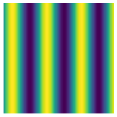

```python
def p(x, y): return np.sin(20 * x)
plt.axis('off'); plt.imshow(p(x, y), cmap=cm.viridis);
```

### Generative art - using grammars

"I'd rather write programs that write programs than write programs" -- Richard Sites

Notice that we can also write functions like `p(x, y)` as pure strings, using `eval` as follows:

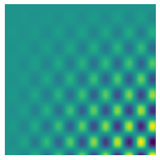

```python
ps = "np.sin(40 * x) * np.sin(30 * (y+0.5)) * x * y"
p = eval("lambda x, y: " + ps)
plt.axis('off'); plt.imshow(p(x, y));
```

### Exercise

Make a new grammar for *arithmetical expressions in x and y*. Start by copying `code/boolean.bnf` to a new file `code/arithmetic.bnf`. Generate random expressions from that, turn them into functions using `eval`, and visualise them. Try out different colormaps with `cmap`. Think of some more interesting primitive functions to use other than `*`, `sin`, and friends. You can even create more variables (beyond $x$ and $y$), e.g. polar coordinates $r$ and $\theta$.

### Solution

The file `code/arithmetic.bnf` file is supplied with this week's materials.

[figure not shown]

# Introspection

Introspection means looking inward to the self. In programming, it refers to a few ways in which a program can inspect its own properties **while running** (as distinct from **at compile-time**).

- Finding out the type of an object;
- Accessing docstrings, function names, and other function properties;
- Accessing filenames and line numbers of the source file;
- Accessing the call stack (what functions called what functions to lead us to *here*);
- Accessing the configuration of the interpreter.

A lot of people think that introspection is a key ingredient in consciousness and intelligence! So it's relevant to AI in this sense. But we will think of introspection as a handy tool for programming in general.

In `C` and other older languages, even detecting the length of an array at runtime was not possible. So to a C programmer, Python's `len(a)` would seem like introspection.

Given an arbitrary object, there are several easy ways to find out about it -- some we've seen already -- and these are more like true introspection:

- `type`: what type is it?
- `dir`: what methods does it have?
- `repr`: see a useful string representation, may be valid Python code.
- `help`: access the docstring.

Some new ones, quite self-explanatory:

- `callable(f)`: is `f` callable (i.e. is `f(...)` allowed)?
- `issubclass(D, C)`: is `D` a subclass of `C`? (Works on classes, not objects.)
- `isinstance(c, C)`: check if `c` is an instance of `C` (allowing for subclasses).

```python
def f(): pass
x = 17
class C:
    def __call__(self):
        return "Objects can quack like functions"
c = C()
print(callable(f))
print(callable(x))
print(callable(C))
print(callable(c))
c()
```

```
True
False
True
True
```

```
'Objects can quack like functions'
```

```python
class C: pass
class D(C): pass
class E(D): pass
print(issubclass(D, C))
print(issubclass(E, C))
print(issubclass(C, D))
```

```
True
True
False
```

```python
c = C()
d = D()
print(isinstance(c, C))
print(isinstance(d, D))
print(isinstance(c, D))
print(isinstance(d, C))
```

```
True
True
False
True
```

Classes and functions have official names. The official name is the one written in the source following `class` or `def`. This is distinct from the object's variable name!

- `x.__name__`: get the "official" name of `x` which must be a function or a class

```python
def f(a, b):
    return a + b
g = f # g is f, and has the same official name:
print(f.__name__)
print(g.__name__)
```

```
f
f
```

This could be useful e.g. when testing some Scikit-Learn models:

```python
from sklearn.linear_model import LogisticRegression
from sklearn.neighbors import KNeighborsClassifier

for clf in [LogisticRegression(solver="lbfgs"),
            KNeighborsClassifier(n_neighbors=1)]:
    s = clf.fit([[3, 4], [3, 5]], [0, 1]).score([[4, 4]], [0])
    print(clf.__class__.__name__, s)
```

```
LogisticRegression 1.0
KNeighborsClassifier 1.0
```

### Accessing variables and values in a namespace

Each returns a `dict`:

- `globals()`: variables in the module namespace
- `locals()`: variables in the current namespace
- `vars()`: same as `locals()`
- `vars(d)`: variables in namespace `d` where e.g. `d` is some module.

### `hasattr`

"Frameworks use introspection frequently, to discover the capabilities of objects the user has passed; for example, "does this object's class have a `do_something()` method? If so, call the object's `do_something()`; otherwise call the `do_something_similar()` framework function with the object as an argument.""

-- http://archive.oreilly.com/oreillyschool/courses/Python4/Python4-09.html.

`hasattr(obj, attr)` tells us whether an object has a particular attribute.

Using introspection and `hasattr`, we check that our code will work before running it.

```python
def check_initial(x):
    if hasattr(x, "startswith"):
        print(x.startswith("C"))
    else:
        print(x.__class__.__name__.startswith("C"))
check_initial("CDEFG")
```

```
True
```

In the **duck typing** style, we instead assume `x` has `a` (and maybe catch a possible exception). We say "it is easier to ask forgiveness than permission" (EAFP):

```python
def check_initial(x):
    try:
        print(x.startswith("C"))
    except AttributeError:
        print(x.__class__.__name__.startswith("C"))
check_initial(C())
```

```
True
```

### Version numbers for Python and libraries

These are useful:

1. To catch possible incompatibilities between your code and an old version of a library;
2. When reporting bugs on Github and asking questions on Stackoverflow.

```python
import sys
print(sys.version)
import numpy as np
print(np.version)
import sklearn
print(sklearn.__version__)
```

```
3.7.3 (default, Mar 27 2019, 22:11:17)
[GCC 7.3.0]
<module 'numpy.version' from '/home/jmmcd/anaconda3/lib/python3.7/site-packages/numpy/version.py'>
0.21.2
```

### Some more possibilities

- Find out what source file an object was defined in, and at what line number (`inspect.getmembers()`);
- Find out which function called the function we are currently in (`inspect.getmembers()`);
- Given a function, find out what arguments (and types) it expects (`inspect.Signature`).

### Example: getting at the data in a JSON file

Suppose we have a JSON file and we don't know anything about its structure. We can use the `json` module to read it in to native Python datatypes. We'll use introspection to understand the structure.

```python
import json
d = json.load(open("data/students.json"))
```

Notice that (just like `pickle.load` and `pickle.dump` which we saw before), `json.load` expects an open file, not a filename. Same for `json.dump`.

```python
d
```

```
[{'name': 'Bruce Wayne',
  'age': 34,
  'ID': '1234',
  'modules': {'CT5123': {'grades': [55, 68],
    'attendance': [False, True, True, True, True]},
   'CT5234': {'grades': [45, 90],
    'attendance': [True, False, False, False, True]}}},
 {'name': 'Peter Parker',
  'age': 21,
  'ID': '0126',
  'modules': {'CT5123': {'grades': [90, 90, 90],
    'attendance': [False, True, True, True, True]},
   'CT5234': {'grades': [60, 74],
    'attendance': [False, True, True, True, True]}}}]
```

```python
type(d)
```

```
list
```

```python
type(d[0])
```

```
dict
```

```python
d[0].keys()
```

```
dict_keys(['name', 'age', 'ID', 'modules'])
```

```python
d[0]["name"]
```

```
'Bruce Wayne'
```

```python
d[0]["age"]
```

```
34
```

```python
d[0]["ID"]
```

```
'1234'
```

```python
d[0]["modules"]
```

```
{'CT5123': {'grades': [55, 68], 'attendance': [False, True, True, True, True]},
 'CT5234': {'grades': [45, 90],
  'attendance': [True, False, False, False, True]}}
```

```python
type(d[0]["modules"])
```

```
dict
```

... and so on.

Downey provides a nice function `structshape` for doing this automatically and summarising the result. See example below and see Think Python, p. 120. The code is in `code/structshape.py`.

```python
from code.structshape import structshape
structshape(students)
```

```
'list of (dict of 4 str->(int, dict of 2 str->dict of 2 str->(list of 2 int, list of 5 bool), str), dict of 4 str->(int, dict of 2 str->(dict of 2 str->(list of 3 int, list of 5 bool), dict of 2 str->(list of 2 int, list of 5 bool)), str))'
```

[figure not shown]

# Memoization

"Those who cannot remember the past are doomed to repeat it"

-- George Santayana, quoted by https://blog.usejournal.com/top-50-dynamic-programming-practice-problems-4208fed71aa3

Memoization (not memo**R**ization): if a function

- may be called often with the same arguments, and
- is deterministic, and
- has no side effects, and
- this is enough to make our program slow; then

it might be better to *store* the result the first time it's calculated, and in future save time by just returning that result.

It was called a machine learning technique when it was invented, and according to some definitions, it is.

In this notebook, we'll motivate the idea with an example, and then we'll implement the idea for understanding. Then we'll see how to take advantage of Python's own implementation instead.

Recall the Fibonacci numbers:

```python
def fibonacci(n):
    if n in (0, 1):
        return n
    else:
        return (fibonacci(n - 1) +
                fibonacci(n - 2))
```

```python
fibonacci(10)
```

```
55
```

For small $n$, this is fine. But for even slightly larger $n$, it becomes slow!

```python
# this % magic works in IPython
# or Jupyter Notebook
%timeit fibonacci(35)
```

```
2.84 s ± 6.63 ms per loop (mean ± std. dev. of 7 runs, 1 loop each)
```

A lot of time is being wasted here. Let's see:

```python
def fibonacci(n):
    print(f"Calculating fibonacci({n})")
    if n in (0, 1):
        return n
    else:
        return (fibonacci(n - 1) +
                fibonacci(n - 2))
```

```python
fibonacci(10)
```

```
Calculating fibonacci(10)
Calculating fibonacci(9)
Calculating fibonacci(8)
Calculating fibonacci(7)
Calculating fibonacci(6)
Calculating fibonacci(5)
Calculating fibonacci(4)
Calculating fibonacci(3)
Calculating fibonacci(2)
Calculating fibonacci(1)
Calculating fibonacci(0)
Calculating fibonacci(1)
Calculating fibonacci(2)
Calculating fibonacci(1)
Calculating fibonacci(0)
Calculating fibonacci(3)
Calculating fibonacci(2)
Calculating fibonacci(1)
Calculating fibonacci(0)
Calculating fibonacci(1)
Calculating fibonacci(4)
Calculating fibonacci(3)
Calculating fibonacci(2)
Calculating fibonacci(1)
Calculating fibonacci(0)
Calculating fibonacci(1)
Calculating fibonacci(2)
Calculating fibonacci(1)
Calculating fibonacci(0)
Calculating fibonacci(5)
Calculating fibonacci(4)
Calculating fibonacci(3)
Calculating fibonacci(2)
Calculating fibonacci(1)
Calculating fibonacci(0)
Calculating fibonacci(1)
Calculating fibonacci(2)
Calculating fibonacci(1)
Calculating fibonacci(0)
Calculating fibonacci(3)
```

[output cut: 122 more lines]

```
Calculating fibonacci(0)
Calculating fibonacci(3)
Calculating fibonacci(2)
Calculating fibonacci(1)
Calculating fibonacci(0)
Calculating fibonacci(1)
Calculating fibonacci(4)
Calculating fibonacci(3)
Calculating fibonacci(2)
Calculating fibonacci(1)
Calculating fibonacci(0)
Calculating fibonacci(1)
Calculating fibonacci(2)
Calculating fibonacci(1)
Calculating fibonacci(0)
```

```
55
```

Look at that: we are re-computing `fibonacci(0)`, `fibonacci(1)`, etc., over and over! Why does that happen? Well, look at the **call graph**:

[figure not shown]

From Downey, *Think Python*

The solution to this is memoization. Very simply, we create a *cache* of known results, and consult it before running the function. We'll do it in a simple but Fibonacci-specific way first, and then see a way to generalise it.

```python
# From Downey, Think Python
cache = {0: 0, 1: 1} # F0 and F1
def fibonacci_mem(n):
    if n in cache:
        return cache[n]
    print(f"Calculating fibonacci_mem({n})")
    cache[n] = fibonacci_mem(n - 1) + fibonacci_mem(n - 2)
    return cache[n]
```

```python
fibonacci_mem(10)
```

```
Calculating fibonacci_mem(10)
Calculating fibonacci_mem(9)
Calculating fibonacci_mem(8)
Calculating fibonacci_mem(7)
Calculating fibonacci_mem(6)
Calculating fibonacci_mem(5)
Calculating fibonacci_mem(4)
Calculating fibonacci_mem(3)
Calculating fibonacci_mem(2)
```

```
55
```

The above is great and it works. The same technique can be used for other functions.

But with this approach, for each function we want to memoize, we have to go in and edit that function. It would be nicer if we could write the memoization idea just once, and then (*lego-like*) combine that with any existing function. Well, we can!

```python
def fibonacci(n):
    print(f"Calculating fibonacci({n})")
    if n in (0, 1):
        return n
    else:
        return (fibonacci(n - 1) +
                fibonacci(n - 2))
```

Here is the higher-order trick which allows us to memoize any function `f`: we define one fn inside another.

```python
def memoize(f):
    cache = {}
    def mem_f(*args):
        if args in cache: # "cache hit"
            return cache[args]
        else: # "cache miss"
            cache[args] = f(*args)
            return cache[args]
    return mem_f
```

```python
# memoize our *original* fibonacci function
fibonacci = memoize(fibonacci)
fibonacci(10)
```

```
Calculating fibonacci(10)
Calculating fibonacci(9)
Calculating fibonacci(8)
Calculating fibonacci(7)
Calculating fibonacci(6)
Calculating fibonacci(5)
Calculating fibonacci(4)
Calculating fibonacci(3)
Calculating fibonacci(2)
Calculating fibonacci(1)
Calculating fibonacci(0)
```

```
55
```

`memoize` is a higher-order function: it takes a function as an argument and returns another function.

Notice that above, we don't assume that the arguments to `f` will always be just `n`. They could be anything. So we capture the arguments in `*args` and then pass that when calling `f` inside `mem_f`.

### Closures

- When we try to use `mem_f` elsewhere, `memoize` doesn't seem to exist anymore! It has finished! Shouldn't its namespace be deleted? How can `mem_f` access `cache`?

By the way, above the function `mem_f` was defined *inside* another function `memoize` (and then it was returned). That's ok. But an interesting question arises. `mem_f` has to access some data -- `cache` -- which was also defined inside `memoize`. We expect it to have access to `cache` because the environment model says we can accesss names like `cache` in the enclosing namespace, that of `memoize`. But when we return and try to use `mem_f` elsewhere, `memoize` doesn't seem to exist anymore! It has finished! Shouldn't its namespace be deleted?

Well, this is a special case: Python knows that this will happen, so it keeps the necessary data alive in a special data structure which goes everywhere with `mem_f`. Together, they are called a *closure*.

### Decorators

The pattern

```
fibonacci = memoize(fibonacci)
```

is a common one with HOFs which take in one function argument and return some variant of it. There is a special *decorator* syntax which basically does that for us:

```python
@memoize
def fibonacci(n):
    if n in (0, 1):
        return n
    else:
        return (fibonacci(n - 1) +
                fibonacci(n - 2))
```

```python
fibonacci(10)
```

```
55
```

Memoization is a useful trick, so it's not a surprise that it's provided as a decorator in the standard library. It's usually better to use this than to write it ourselves.

```python
import functools
@functools.lru_cache(maxsize=100)
def fibonacci(n):
    if n in (0, 1):
        return n
    else:
        return (fibonacci(n - 1) +
                fibonacci(n - 2))
```

### Arguments must be hashable

We are going to put `*args` into a `dict`, so the arguments must be **hashable**. If not, it fails!

```python
@functools.lru_cache(maxsize=100)
def f(L): return len(L)
f([4, 5, 6])
```

```
---------------------------------------------------------------------------
TypeError                                 Traceback (most recent call last)
<ipython-input-8-5e4dc13772e9> in <module>
      1 @functools.lru_cache(maxsize=100)
      2 def f(L): return len(L)
----> 3 f([4, 5, 6])
      4

TypeError: unhashable type: 'list'
```

### Cache replacement

- `maxsize` versus unlimited
- LRU, FIFO, LFU
- RAM v CPU trade-off

In our `memoize`, the cache was unlimited in size. In some situations it could grow very big and steal all our RAM.

In `functools.lru_cache`, we can control how large the cache is allowed to become using `maxsize`. Use `maxsize=None` for no limit on size.

[figure not shown]

# $n$-grams, randomness, and the Aaronson oracle

The Aaronson oracle is about the simplest possible computer game, but it really makes you think. We'll describe it and see how to get the computer to play it using a very broadly applicable technique, $n$-grams. We'll start with motivation.

### Which of these is random?

From [telescoper](https://telescoper.wordpress.com/2009/04/04/points-and-poisson-davril/) via [Discover magazine](http://blogs.discovermagazine.com/cosmicvariance/2009/04/06/perceiving-randomness/#.XcLxeNHLfeR)

It turns out that humans are very bad at detecting randomness. We're so good at detecting patterns that we detect them even when they're not there!

The same thing could happen in other settings. Which of these is random?

- 10011000110100011000111010100010110000110001111110
- 01001010010101010001001001011010101101010110101100

The [Aaronson oracle](https://github.com/elsehow/aaronson-oracle) is a game invented by Scott Aaronson (a top researcher in computational complexity and quantum computing, and he has a [great blog](https://www.scottaaronson.com/blog/)) to probe the idea of randomness.

- The human types '0' or '1' (or 'f' or 'd', or left-arrow or right-arrow, whatever) -- should be fairly quick.
- The computer has made a guess which it will be.
- We repeat many times (the human should type fairly quickly). The computer has access to the history.
- If the computer's accuracy is near 50%, the human wins. If high (e.g. 65%), the computer wins.

The program is just a loop which makes a prediction (let's just predict randomly for now), reads in the user's move, saves both to a history, and calculates a running accuracy.

```
move_hist = []
    pred_hist = []
    while True:
        # generate a prediction, just placeholder
        prediction = random.choice("01")

        # read user's move
        user_move = getch()

        # store to history
        move_hist.append(user_move)
        pred_hist.append(prediction)

        # stats
        accuracy = np.mean([p == u for p, u in
                    zip(pred_hist, move_hist)])
        print(f"prediction: {prediction}; " +
              f"user played {user_move}; " +
              f"accuracy {accuracy}")
```

### `input` and `getch`

In Python, there is a function `input()` (a component of the read-eval-print loop!) which gets a line from the user.

But that won't work here because the user would have to type 0 `<return>` or 1 `<return>` each time which would be slow and could change their behaviour.

Instead, there is a small module `code/getchar.py` which reads one character at a time, available here:

- https://stackoverflow.com/q/510357/86465
- http://code.activestate.com/recipes/134892/

Our remaining task is to implement a method of predicting the user's move. There are many possible approaches, each of which makes some implicit assumptions about the patterns that will be present despite the user's intentions. We'll use a very simple method which performs amazingly well: $n$-grams.

- Suppose we observe that whenever the user types `01010` they usually type `1` next. That means that whenever we observe `01010` we should predict `1`.

### $n$-grams

An $n$-gram is an $n$-tuple of consecutive objects drawn from a sequence. For example in the sentence "it was the best of times, it was the worst of times", we have the following 3-grams:

(it was the), (was the best), (the best of), (best of times), etc.

$n$-grams have applications in language modelling and generation, both for natural language and formal languages, and even the "language" of music.

Here, we will use $n$-grams to make predictions. Let's choose $n=5$. For every possible 5-gram, we'll track how often it is followed by a `0` and how often by a `1`.

Suppose we have the string `010101001`. Then we get these observations:

```
01010 -> 1
10101 -> 0
01010 -> 0
10100 -> 1
```

We'll represent each observation as a 2-tuple, e.g. `("01010", "1")`. We'll just put the tuples in a `Counter`, which is a specialised `defaultdict`.

```
from collections import Counter
c = Counter()
c["01010", "1"] += 1
c["10101", "0"] += 1
```

etc.

Then whenever we observe a string `"01010"`, we just check which has the highest frequency in the data so far: `("01010", "0")`, or `("01010", "1")`.

Amazingly, this is good enough to perform quite well! The full program is in `code/aaronson_oracle.py`:

```
$ cd code
$ python aaronson_oracle.py
```

### Exercises

- Play the game a few times and see how you get on. Remember, you're supposed to play quickly.
- Tell it to read the $n$-grams from a previously-saved file if it exists, and to write an updated version at the end, e.g. `python aaronson_oracle.py ngrams.txt`.
- Look at the Counter that is saved in `ngrams.txt` and see if you can see your own weakness.
- Change $n$ and see if it gets better or worse.

### Exercises (only for fun):

1. Write an ML program using Scikit-Learn which can perform better than the n-gram program, ie better than 60% against a typical human.
2. Write a deterministic player which can defeat the program, ie keep it close to 50%.
3. Try playing your deterministic player (2) against your friend's enhanced predictor (1).
4. Try playing against your friends manually.

[figure not shown]

# The Fourier Transform and Spectrogram

Fourier: any signal is a sum of sinusoidal signals.

Helmholtz: any sound is a sum of sinusoidal tones.

Tangent: "Fourier's consideration of the possibility that the Earth's atmosphere might act as an insulator of some kind is widely recognized as the first proposal of what is now known as the greenhouse effect" (Wikipedia)

The Fourier transform is a core building-block of the study of signals. It decomposes a signal into a sum of sinusoidal signals of different frequencies. We can then see how much *energy* is present at each frequency.

[figure not shown]

http://mriquestions.com/fourier-transform-ft.html

The **Discrete** Fourier Transform is a definition of the FT, suitable for use with time series (i.e. signals which are sampled at discrete, regular intervals, rather than continuous).

The **Fast** Fourier Transform (Cooley & Tukey, 1965) computes the Discrete Fourier Transform, fast. It was named as one of the top 10 algorithms of the 20th century!

https://www.computer.org/csdl/magazine/cs/2000/01/c1022/13rRUxBJhBm

This amazing animation shows how the Fourier transform can arise in unexpected places: http://www.jezzamon.com/fourier/

First, we'll see how to run the FFT on a short time series of generated audio.

```python
import numpy as np
import matplotlib.pyplot as plt
import scipy.fftpack
%matplotlib inline
```

```python
L = 0.01 # 0.01s of audio
fs = 44100 # sampling rate
N = int(L * fs) # number of samples
# time values, linearly spaced
t = np.linspace(0, L, N, endpoint=False)
f1, f2 = 220.0, 2200.0
x = (np.sin(2 * np.pi * t * f1) +
     np.sin(2 * np.pi * t * f2))
```

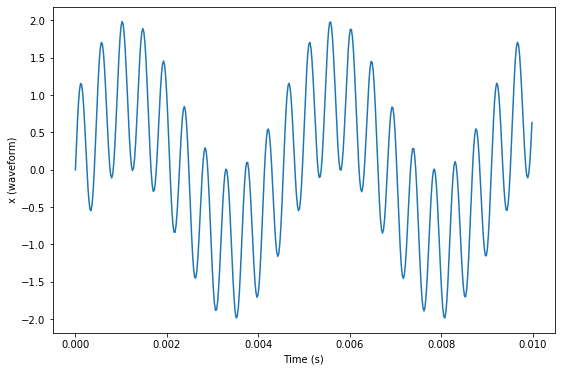

```python
plt.plot(t, x)
plt.xlabel("Time (s)")
plt.ylabel("x (waveform)");
```

```python
X = scipy.fftpack.fft(x) # FT
# discard the second half of FT with [:N//2]
# and discard the imaginary part (phase) with abs
X = np.abs(X[:N//2])
print(X.shape)
```

```
(220,)
```

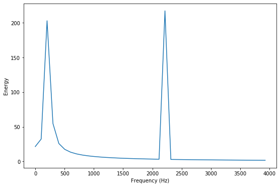

```python
# calculate the frequency for each DFT bin
F = np.linspace(0.0, fs / 2, N//2)
# plot only the low-frequency components
plt.plot(F[:40], X[:40])
plt.xlabel(r"Frequency (Hz)"); plt.ylabel("Energy");
```

### Anomaly detection in audio

Suppose we are working on preventive maintainence of industrial machinery. That is: we want to detect and predict possible problems in machines, and take them out of service for maintainence, before they break down.

One method we might use is audio recordings of the machines. A good mechanic is often able to diagnose car problems by ear, so maybe the same is true for our machines.

### Spectrogram

Because we have long recordings, we split the time-domain waveform into many short (overlapping) *windows* and for each, calculate the FT. That gives the *spectrogram*.

Now we have a 2D matrix: frequency versus time. The value indicates the *energy* in each frequency bin, at each time-step.

[figure not shown]

```python
import scipy.io
import scipy.io.wavfile
import scipy.signal
```

```python
fs, x = scipy.io.wavfile.read("data/furnace.wav")
print(fs) # sampling rate
print(x.shape)
```

```
44100
(367616,)
```

Let's look at the audio recording:

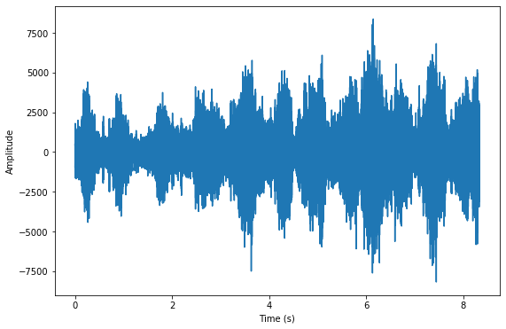

```python
t = np.linspace(0, x.shape[0] / fs, x.shape[0])
plt.plot(t, x)
plt.ylabel('Amplitude'); plt.xlabel('Time (s)');
```

Let's zoom in:

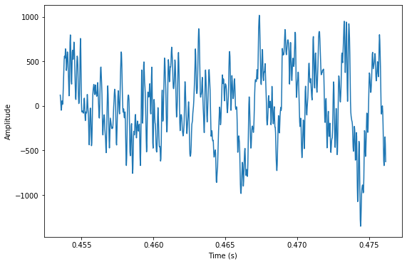

```python
t = np.linspace(0, x.shape[0] / fs, x.shape[0])
plt.plot(t[20000:21000], x[20000:21000])
plt.ylabel('Amplitude'); plt.xlabel('Time (s)');
```

The `spectrogram` function computes the whole spectrogram and discards uninteresting parts to give `X`. It gives `f` and `t` with the frequency and time values for each "cell" in `X`. We pass in the window length in samples (usually a power of two).

```python
f, t, X = scipy.signal.spectrogram(x, fs=fs,
                                   nperseg=4096)
print(f.shape)
print(t.shape)
print(X.shape)
```

```
(2049,)
(102,)
(2049, 102)
```

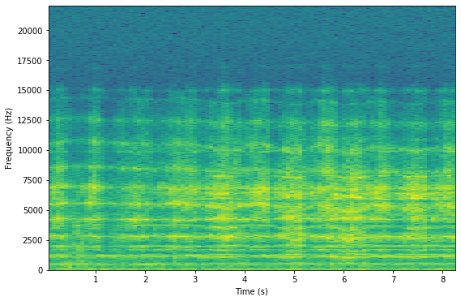

```python
plt.pcolormesh(t, f, np.log(X));
plt.ylabel('Frequency (Hz)');
plt.xlabel('Time (s)');
```

So far, we can't see anything useful. But suppose we know what the "warning signs" are like: let's zoom in on the lowest frequencies:

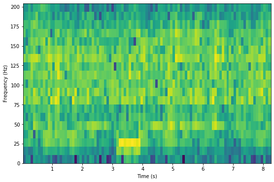

```python
plt.pcolormesh(t, f[:20], np.log(X[:20, :]));
plt.ylabel('Frequency (Hz)');
plt.xlabel('Time (s)');
```

Now we can see a very strong signal: between 3 and 4s there is an anomalous sound around 25Hz not present elsewhere.

That was not audible nor visible in the original waveform!

We can now program a system to automatically flag large values in that band for inspection and maintainence.

If we don't know in advance what the "warning signs" are like, we could instead program an ML algorithm to detect any type of anomaly.

### What else can we use this for?

- The spectrogram contains more meaningful ("high-level") features than the raw data, so:
- Machine learning on audio (e.g. speech processing) usually starts with the spectrogram, eg:
- Shazam (automated song recognition in noisy environments) uses peaks in the spectrogram.
- Also non-audio signals: weather, stock markets, astronomy, ...